# Introduction to R-INLA and INLAjoint

Bayesian survival, longitudinal and joint models with INLA VIBASS 9, Valencia, Spain

Denis Rustand

July 8 and 9, 2026

## The R package INLA (R-INLA)

The `R-INLA` package implements the Integrated Nested Laplace Approximations methodology in R. It computes approximate posterior density functions for latent Gaussian models.

The interface is very general. It offers robust capabilities for advanced models but it requires specific knowledge and coding skills to specify complex structures.

### Installation

You can install the package directly from the repository:

```r
install.packages("INLA",
                 repos=c(getOption("repos"),
                        INLA="https://inla.r-inla-download.org/R/stable"), dep=TRUE)
```

### The inla() function

The main function to fit a model is `inla()`. It requires three main arguments: `formula`, `data` and `family`.

Fixed effects are added with `+`. Random effects are specified using the `f()` function.

Here is a conceptual example for a logistic regression with a random intercept:

```r
library(INLA)
load("data_example.RData")
result_inla <- inla(y ~ x1 + x2 + f(ID, model = "iid"),
                    data = data_example, family = "binomial")
```

### Extracting results

The fitted object contains posterior summaries and densities for all parameters.

```r
summary(result_inla)
```

```
## Time used:
##     Pre = 0.281, Running = 0.195, Post = 0.0152, Total = 0.492
## Fixed effects:
##               mean    sd 0.025quant 0.5quant 0.975quant   mode kld
## (Intercept) -0.072 0.119     -0.307   -0.072      0.162 -0.072   0
## x1           1.096 0.096      0.909    1.095      1.286  1.095   0
## x2          -1.109 0.096     -1.297   -1.109     -0.922 -1.109   0
##
## Random effects:
##   Name     Model
##     ID IID model
##
## Model hyperparameters:
##                  mean    sd 0.025quant 0.5quant 0.975quant mode
## Precision for ID 1.33 0.425      0.733     1.26       2.36 1.14
##
## Marginal log-Likelihood:  -555.45
##  is computed
## Posterior summaries for the linear predictor and the fitted values are computed
## (Posterior marginals needs also 'control.compute=list(return.marginals.predictor=TRUE)')
```

You can extract the posterior summaries of the fixed effects:

```r
result_inla$summary.fixed
```

```
##                    mean         sd 0.025quant    0.5quant 0.975quant
## (Intercept) -0.07225875 0.11918328 -0.3071696 -0.07210632  0.1617877
## x1           1.09584975 0.09614606  0.9086368  1.09538308  1.2857160
## x2          -1.10884990 0.09562705 -1.2972935 -1.10852679 -0.9222437
##                    mode          kld
## (Intercept) -0.07210709 1.948434e-08
## x1           1.09537978 6.055618e-09
## x2          -1.10852467 2.944466e-09
```

```r
result_inla$marginals.fixed
```

```
## $`(Intercept)`
##                  x            y
##  [1,] -0.609275144 0.0003564656
##  [2,] -0.535956600 0.0028779573
##  [3,] -0.451396692 0.0255161298
##  [4,] -0.352945551 0.2115710752
##  [5,] -0.307169586 0.4729424510
##  [6,] -0.268429915 0.8465781776
##  [7,] -0.224354032 1.4608067404
##  [8,] -0.194918192 1.9556909504
##  [9,] -0.171665689 2.3601804290
## [10,] -0.151798919 2.6886687890
## [11,] -0.134002318 2.9497461462
## [12,] -0.117561681 3.1484733985
## [13,] -0.109678624 3.2258037587
```

[output cut: 122 more lines]

You can plot these densities directly:

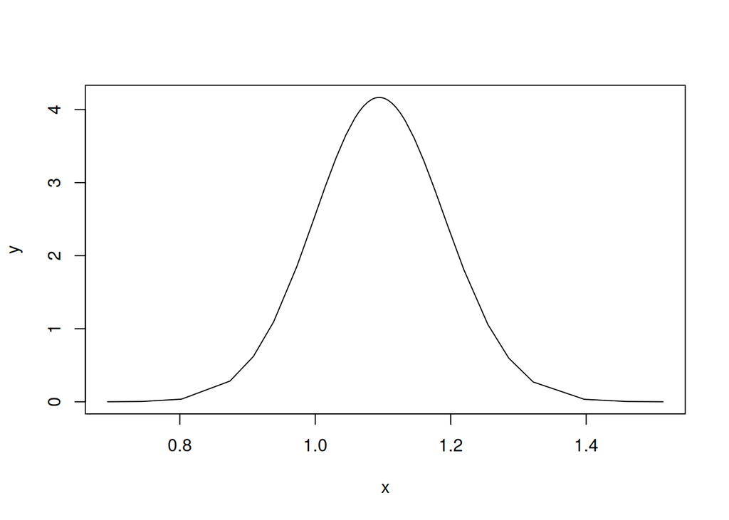

```r
plot(result_inla$marginals.fixed$x1, type = "l")
```

For random effects or hyperparameters, you simply replace `fixed` with `random`, `hyperpar`, `fitted.values` or `linear.predictor`.

### Finding documentation internally

INLA supports a massive number of likelihoods and latent models. You can explore them directly in the R console:

```r
# List all available likelihood families
names(inla.models()$likelihood)
```

```
##   [1] "fl"                            "poisson"
##   [3] "npoisson"                      "nzpoisson"
##   [5] "xpoisson"                      "cenpoisson"
##   [7] "cenpoisson2"                   "gpoisson"
##   [9] "poisson.special1"              "0poisson"
##  [11] "0poissonS"                     "1poisson"
##  [13] "1poissonS"                     "bell"
##  [15] "0binomial"                     "0binomialS"
##  [17] "0nbinomial"                    "0nbinomialS"
##  [19] "binomialmix"                   "binomial"
##  [21] "xbinomial"                     "occupancy"
##  [23] "pom"                           "bgev"
##  [25] "gamma"                         "mgamma"
##  [27] "gammasv"                       "gammasurv"
##  [29] "mgammasurv"                    "gammajw"
```

[output cut: 42 more lines]

```r
# Read documentation for a specific likelihood
inla.doc("zeroinflatedpoisson")

# List all available latent models for the f() function
names(inla.models()$latent)
```

```
##  [1] "linear"       "iid"          "mec"          "meb"          "rgeneric"
##  [6] "cgeneric"     "rw1"          "rw2"          "crw2"         "prw2"
## [11] "seasonal"     "besag"        "besag2"       "bym"          "bym2"
## [16] "besagproper"  "besagproper2" "fgn"          "fgn2"         "ar1"
## [21] "ar1c"         "ar"           "ou"           "intslope"     "generic"
## [26] "generic0"     "generic1"     "generic2"     "generic3"     "spde"
## [31] "spde2"        "spde3"        "iid1d"        "iid2d"        "iid3d"
## [36] "iid4d"        "iid5d"        "iidkd"        "2diid"        "z"
## [41] "rw2d"         "rw2diid"      "slm"          "matern2d"     "dmatern"
## [46] "copy"         "scopy"        "clinear"      "sigm"         "revsigm"
## [51] "log1exp"      "logdist"
```

```r
# List available priors
names(inla.models()$prior)
```

```
##  [1] "normal"                 "gaussian"               "laplace"
##  [4] "linksnintercept"        "wishart1d"              "wishart2d"
##  [7] "wishart3d"              "wishart4d"              "wishart5d"
## [10] "loggamma"               "gamma"                  "pc.prw2.range"
## [13] "minuslogsqrtruncnormal" "logtnormal"             "logtgaussian"
## [16] "flat"                   "logflat"                "logiflat"
## [19] "mvnorm"                 "pc.alphaw"              "pc.ar"
## [22] "dirichlet"              "none"                   "invalid"
## [25] "betacorrelation"        "logitbeta"              "pc.prec"
## [28] "pc.dof"                 "pc.cor0"                "pc.cor1"
## [31] "pc.fgnh"                "pc.spde.GA"             "pc.matern"
## [34] "pc.range"               "pc.sn"                  "pc.gamma"
## [37] "pc.mgamma"              "pc.gammacount"          "pc.gevtail"
## [40] "pc.egptail"             "pc"                     "ref.ar"
## [43] "pom"                    "jeffreystdf"            "wishartkd"
## [46] "expression:"            "table:"                 "rprior:"
```

## The R package INLAjoint

To address the coding complexity of `R-INLA` for multiple outcomes, the `INLAjoint` package was developed. It provides a user interface tailored for survival, longitudinal and joint data analysis.

It replaces error-prone coding with an intuitive framework. It also includes post-processing functions to extract predictions, hazard ratios and survival probabilities easily.

### Installation

`INLAjoint` is available on CRAN:

```r
install.packages("INLAjoint")
```

The development version is available on GitHub:

```r
devtools::install_github("DenisRustand/INLAjoint")
```

### The joint() function

The primary model-fitting function is `joint()`. It uses a building blocks syntax.

```r
joint(
  formSurv = NULL, formLong = NULL, dataSurv = NULL, dataLong = NULL,
  id = NULL, timeVar = NULL, family = "gaussian", link = "default",
  basRisk = "rw1", NbasRisk = 15, cutpoints = NULL, assoc = NULL,
  assocSurv = NULL, corLong = FALSE, corRE = TRUE, dataOnly = FALSE,
  longOnly = FALSE, silentMode = FALSE, reorder = TRUE, run = TRUE,
  control = list()
)
```

Missing values in the outcomes are handled automatically. INLA replaces them with their posterior mean during the fitting process. Missing values in covariates are not allowed.

### Important control options

The `control` argument allows you to tune the fitting procedure:

- `int.strategy`: The numerical integration strategy for hyperparameters. Options include `"auto"`, `"ccd"`, `"grid"` and `"eb"`. We often use `"eb"` (empirical Bayes) to speed up computations without degrading frequentist properties.
- `safemode`: A boolean (default TRUE) that automatically reruns the model with adjusted starting values if it detects instability.
- `run`: A boolean (default TRUE). If set to FALSE, the function builds the model structure but does not run the INLA algorithm. This “build only” option allows you to manually modify priors or structures before fitting.

## A quick tour of INLAjoint outputs

We will detail the math behind survival, longitudinal and joint models in the upcoming sessions. For now, let’s fit a complex model just to see how `INLAjoint` handles syntax, outputs and plotting.

We use the `pbc2` dataset. We model two longitudinal markers (SGOT and platelets) and one survival outcome (death).

```r
library(INLA)
library(INLAjoint)
library(JMbayes2) # Contains the pbc2 data

data("pbc2.id")
data("pbc2")
```

We fit the model by providing lists of formulas:

```r
IJ <- joint(formSurv = list(inla.surv(years, status2) ~ drug),
            formLong = list(SGOT ~ year * drug + (1|id),
                            platelets ~ year * drug + (1|id)),
            dataLong = pbc2, dataSurv = pbc2.id, id = "id",
            timeVar = "year", corLong = TRUE, basRisk = "weibullsurv",
            family = c("lognormal", "poisson"), assoc = c("CV", "CV"),
            control = list(int.strategy = "eb"))
```

### The summary function

The `summary` function returns results grouped by outcome.

Of note, adding `sdcor = TRUE` displays standard deviations and correlations instead of variances and covariances. Adding `hr = TRUE` automatically converts survival fixed effects into hazard ratios.

```r
summary(IJ)
```

```
## Longitudinal outcome (L1, lognormal)
##                         mean     sd 0.025quant 0.5quant 0.975quant
## Intercept_L1          4.7969 0.0392     4.7200   4.7969     4.8739
## year_L1              -0.0050 0.0038    -0.0125  -0.0050     0.0025
## drugDpenicil_L1      -0.1545 0.0553    -0.2628  -0.1545    -0.0462
## year:drugDpenicil_L1 -0.0014 0.0053    -0.0118  -0.0014     0.0090
## Res. err. (variance)  0.0942 0.0033     0.0881   0.0942     0.1009
##
## Longitudinal outcome (L2, poisson)
##                         mean     sd 0.025quant 0.5quant 0.975quant
## Intercept_L2          5.5101 0.0322     5.4469   5.5101     5.5733
## year_L2              -0.0478 0.0009    -0.0495  -0.0478    -0.0461
## drugDpenicil_L2      -0.1014 0.0453    -0.1903  -0.1014    -0.0125
## year:drugDpenicil_L2  0.0138 0.0012     0.0114   0.0138     0.0162
##
## Random effects variance-covariance
##                              mean     sd 0.025quant 0.5quant 0.975quant
## Intercept_L1               0.2055 0.0184     0.1711   0.2048     0.2455
## Intercept_L2               0.1599 0.0132     0.1373   0.1589     0.1894
## Intercept_L1:Intercept_L2 -0.0248 0.0110    -0.0459  -0.0248    -0.0037
##
## Survival outcome
##                      mean     sd 0.025quant 0.5quant 0.975quant
## Weibull (shape)_S1 1.0709 0.0852     0.9446   1.0584     1.2727
## Weibull (scale)_S1 0.0396 0.0048     0.0310   0.0393     0.0498
## drugDpenicil_S1    0.1089 0.1715    -0.2272   0.1089     0.4450
##
## Association longitudinal - survival
##             mean     sd 0.025quant 0.5quant 0.975quant
## CV_L1_S1  1.3704 0.2201     0.9442   1.3680     1.8109
## CV_L2_S1 -1.1335 0.2103    -1.5484  -1.1331    -0.7203
##
## log marginal-likelihood (integration)    log marginal-likelihood (Gaussian)
##                             -45030.27                             -45023.55
##
## Deviance Information Criterion:  45454.27
## Widely applicable Bayesian information criterion:  81938.58
## Computation time: 7.64 seconds
```

```r
summary(IJ, sdcor = TRUE, hr = TRUE)
```

```
## Longitudinal outcome (L1, lognormal)
##                         mean     sd 0.025quant 0.5quant 0.975quant
## Intercept_L1          4.7969 0.0392     4.7200   4.7969     4.8739
## year_L1              -0.0050 0.0038    -0.0125  -0.0050     0.0025
## drugDpenicil_L1      -0.1545 0.0553    -0.2628  -0.1545    -0.0462
## year:drugDpenicil_L1 -0.0014 0.0053    -0.0118  -0.0014     0.0090
## Res. err. (sd)        0.3069 0.0053     0.2967   0.3069     0.3176
##
## Longitudinal outcome (L2, poisson)
##                         mean     sd 0.025quant 0.5quant 0.975quant
## Intercept_L2          5.5101 0.0322     5.4469   5.5101     5.5733
## year_L2              -0.0478 0.0009    -0.0495  -0.0478    -0.0461
## drugDpenicil_L2      -0.1014 0.0453    -0.1903  -0.1014    -0.0125
## year:drugDpenicil_L2  0.0138 0.0012     0.0114   0.0138     0.0162
##
## Random effects standard deviation / correlation
##                              mean     sd 0.025quant 0.5quant 0.975quant
## Intercept_L1               0.4531 0.0203     0.4134   0.4531     0.4927
## Intercept_L2               0.3993 0.0160     0.3699   0.3985     0.4330
## Intercept_L1:Intercept_L2 -0.1348 0.0579    -0.2465  -0.1351    -0.0231
##
## Survival outcome
##                    exp(mean)     sd 0.025quant 0.5quant 0.975quant
## Weibull (shape)_S1    1.0709 0.0852     0.9446   1.0584     1.2727
## Weibull (scale)_S1    0.0396 0.0048     0.0310   0.0393     0.0498
## drugDpenicil_S1       1.1310 0.1921     0.7998   1.1147     1.5536
##
## Association longitudinal - survival
##          exp(mean)     sd 0.025quant 0.5quant 0.975quant
## CV_L1_S1    4.0304 0.8872     2.5874   3.9237     6.0659
## CV_L2_S1    0.3289 0.0686     0.2140   0.3219     0.4830
##
## log marginal-likelihood (integration)    log marginal-likelihood (Gaussian)
##                             -45030.27                             -45023.55
##
## Deviance Information Criterion:  45454.27
## Widely applicable Bayesian information criterion:  81938.58
## Computation time: 7.64 seconds
```